# polySegratioMM: An R library for Bayesian mixture models for marker dosage in autopolyploids

Peter Baker

February 25, 2026

Version: 0.6-5

A Bayesian approach was proposed by Baker, Jackson, and Aitken (2010) where marker dosage estimation was obtained by fitting a finite mixture distribution.

This library calls the `JAGS` software for Bayesian calculation. `JAGS 1.0` or higher must be installed following instructions from (http://mcmc-jags.sourceforge.net/). Note that only the most recent version is used for testing with `R`. The `JAGS` executable must be in your path. Currently, no checking is carried out to ascertain whether or not `JAGS` is set up appropriately.

To use the library, you need to attach it with

```r
library(polySegratioMM)
#: Loading required package: polySegratio
```

# 1 Simulated data

Library functions are demonstrated on a simulated data set generated using the `sim.autoMarkers` function from the `polySegratio` package.

```r
  hexmarkers <- sim.autoMarkers(6,c(0.7,0.2,0.1),n.markers=500,n.individuals=200)
```

```r
print(hexmarkers)
#: Autopolyploid dominant markers generated at Fri Jul 18 14:51:38 2008
#: with call:
#: sim.autoMarkers(ploidy.level = 6, dose.proportion = c(0.7, 0.2,
#:     0.1), n.markers = 500, n.individuals = 200)
#:
#: Ploidy level is: 6 ( Hexaploid )
#: Parents were set as heterogeneous for the markers
#: Theoretical segregation proportions:
#:        ratio.SD        ratio.DD        ratio.TD    ploidy.level
#:           "0.5"           "0.8"          "0.95"             "6"
#:     ploidy.name    type.parents
#:     "Hexaploid" "heterogeneous"
#:
#: Proportions in each dosage class:
#:  SD  DD  TD
#: 0.7 0.2 0.1
#: No. of markers generated from multinomial distribution:
#:    No.markers
#: SD        346
#: DD        103
#: TD         51
#:
#: Data were generated for 200 individuals with 500 markers
#: A subset is:
#:      X.1 X.2 X.3 X.4 X.5 X.6 X.7 X.8 X.9 X.10 r   n   ratio dose
#: M.1  1   0   0   1   0   1   0   1   1   1    108 200 0.54  SD
#: M.2  0   1   1   1   0   1   0   1   0   1    102 200 0.51  SD
#: M.3  1   0   0   1   0   0   0   1   1   1    103 200 0.515 SD
#: M.4  1   1   1   1   1   0   0   0   1   0    97  200 0.485 SD
#: M.5  0   0   1   1   0   0   1   1   0   1    99  200 0.495 SD
#: M.6  1   1   0   0   0   0   0   0   0   0    103 200 0.515 SD
#: M.7  1   1   0   0   0   1   0   0   1   1    101 200 0.505 SD
#: M.8  1   1   1   1   1   1   0   0   0   1    102 200 0.51  SD
#: M.9  0   1   1   1   1   0   0   1   1   0    110 200 0.55  SD
#: M.10 1   0   1   0   1   1   1   0   1   1    108 200 0.54  SD
```

Note that the segregation ratios for simulated or real data may be extracted by using `segregationRatios` which sets up the appropriate objects for testing marker dosage and plotting or summarising the marker data.

```r
sr <-  segregationRatios(hexmarkers$markers)
```

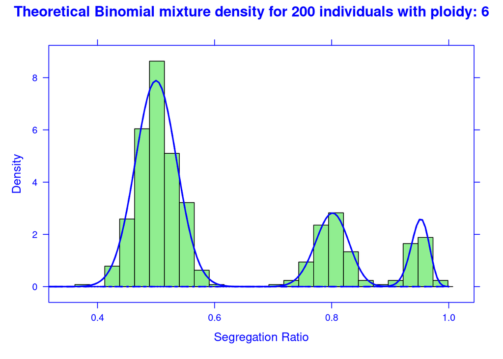

Figure 1.1: Segregation ratios of 500 simulated markers from 200 autohexaploid individuals. Percentages of single, double, and triple dosemarkers are 70%, 20% and 10%, respectively. Data were generated assuming no overdispersion

For instance, as seen in Figure 1.1, segregation ratios may be plotted with

```r
plotTheoretical(ploidy.level=6, seg.ratios=sr,
  expected.segratio=NULL, proportions=c(0.7,0.2,0.1),
  n.individuals=200)
```

On the other hand, consider a similar data set that exhibits overdispersion. This may be simulated as follows

```r
hexmarkers.overdisp <- sim.autoMarkers(6, c(0.7,0.2,0.1),
                                       n.markers=500,n.individuals=200,
                                       overdispersion=TRUE, shape1=30)
```

```r
sr.overdisp <- segregationRatios(hexmarkers.overdisp$markers)
```

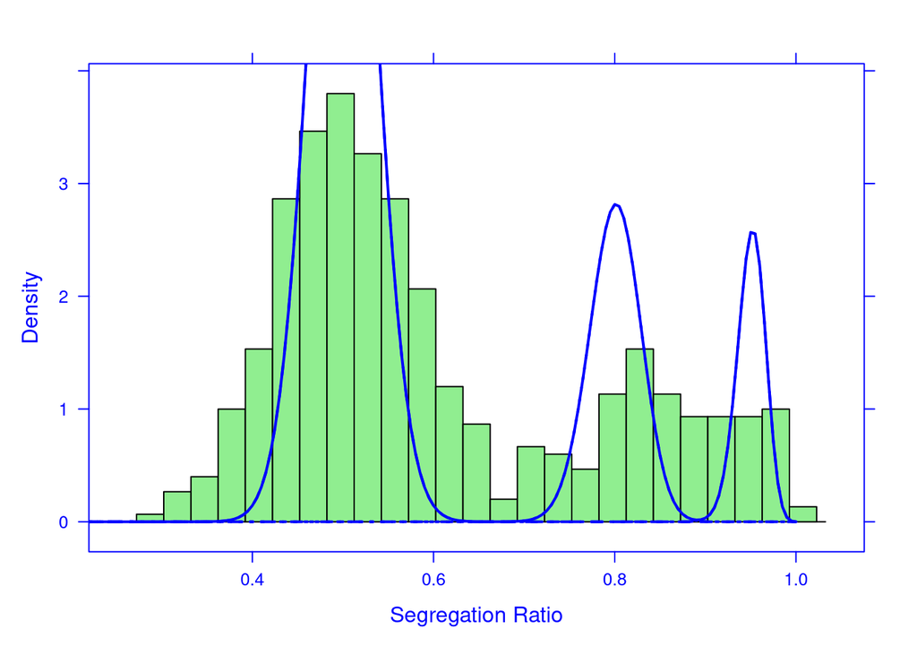

Figure 1.2: Segregation ratios of 500 simulated markers from 200 autohexaploid individuals. Percentages of single double and triple dose markers are 70%, 20% and 10%, respectively. Data were generated from the Beta-Binomial distribution assuming a shape parameter `shape1` of 30.

The histogram of marker segregation ratios, which is a useful graphical method for identifying overdispersion or outliers, is seen in Figure~1.2. Note that, due to overdispersion the theoretical distribution is narrower than the observed data.

# 2 A Bayesian mixture model approach

For the j<sup>th</sup> marker $j=1 \dots n$, we assume the observed number $r_j$ of dominant markers out of $N_j$ lines follows a binomial distribution denoted $Bin(N_j, P_k)$.If we knew the dosage $k$ then, following Ripol et al. (1999), the expected value of $P_k$ may be written as

$$P_k(k| m, x) = 1 - {{{m-k} \choose {mx}} \over {{m} \choose {mx}}}, k=0 \ldots m/2\tag{2.1}$$

here $m$ is the ploidy level or number of homologous chromosomes and the monoploid number $x$ is the number of chromosomes in a basic set. Note that for diploids $m=2$, tetraploids $m=4$ , octaploids then $m=8$ and so on and also that if there are no marker data missing then $N_j$ is simply the number of progeny.

Since the dosage of each marker is unknown, we rely on the missing data representation of Dempster, Laird, and Rubin (1977) and Tanner and Wong (1987) which is commonly adopted for MCMC computation in finite mixture models. An indicator variable $z_j$ corresponding to unknown marker dosage class $k$ is introduced where $z_j = k$ if the marker has dose $k$. For the $K$ components with $K \leq m/2$, consider the logit transformation of the true segregation proportions $P_k$ for dose $k, k=1 \dots K$. The the logit transformed segregation ratio $ _k$ is then

$$\omega_k = \log({ {P_k}\over{1-P_k} })\tag{2.2}$$

Let $z=(z_1 \ldots z_n)^T$ be a vector of unknown dosages (labelled $1,2 \dots K$ corresponding to simplex, duplex, triplex markers and so on), then $r_j$ is binomially distributed with known size parameter $N_j$ and unknown proportion parameter $\omega_{Z_j}$ which is the segregation ratio for marker dosage $z_j$. Hence, given marker dosage $z_j$ then

$$\begin{eqnarray}
r_j|z_j & \sim & Bin \left( N_j, \omega_{Z_j} \right), \\
\mbox{ where } && \nonumber\\
\mbox{logit}( \omega_{Z_j} ) & = & \log ( { \omega_{Z_j} \over 1 - \omega_{Z_
j} } )
\sim N( \mu_{Z_j}, \tau_{Z_j}^{-1})
\nonumber
\end{eqnarray} \tag{2.3}$$

where $\mu_k$ and $\tau_k$ are the mean and precision $(\tau_k = 1/\sigma^2_k)$ of marker dosage class $k$ on the logit scale.

Since the dosage is unknown, for the autohexaploid data generated here then for the logit($\omega_{z_k}$) can be modelled as a finite mixture of 3 normals

$$\mbox{logit}( \omega_{Z_j} ) \sim \pi_1 N(\mu_1,\tau_1^{-1}) +
\pi_2 N(\mu_2,\tau_2^{-1}) + \dots +
\pi_K N(\mu_K,\tau_K^{-1})\tag{2.4}$$

where $\mu_k$ is the mean and $\tau_k$ is the precision of component $k$ on the logit scale, and $\pi_k$ are the mixing proportions of the three components with $\sum_{k=1}^K\pi_k = 1$. The probability density function $f(x)$ of logit($\omega_k$) is

$$f(x) = \sum_{k=1}^K \pi_k \phi(x | \mu_k, \tau^{-1}_k)$$

Simulation studies suggested that incorporating strong prior information, such as the expected distributions of Haldane (1930) provided the best method of allocating dosage. Further details may be found in Baker, Jackson, and Aitken (2010).

# 3 Specifying a model

A mixture model may be set up with `setModel`. By default, only two parameters are required, namely the `ploidy.level` or the number of homologous chromosomes set either as a numeric or as a character string and also `n.components` or the number of components for mixture model (less than or equal to maximum number of possible dosages). By default, strong priors are set by using the formulae of Haldane (1930) for the expected numbers and ratios of offspring for various parental configurations of autopolyploids.

For the autohexaploid data generated above, the models are set with

```r
x.mod1 <- setModel(3,6)  # autohexaploid model with 3 components
```

The `R` object `x.mod1` contains components describing aspects of the model such as the number of components, ploidy, expected segregation ratios and so on. Note that the `str` command is useful for displaying the internal structure of any `R` object.

# 4 Fitting a mixture model

While various options are available for fine tuning the MCMC process, the simplest way to fit a mixture model to allocate marker dosages is with the wrapper function `runSegratioMM} as follows:

```r
mcmcHexRun <- runSegratioMM(sr.overdisp, x.mod1)
```

which automatically determines starting values, priors, length of burn in, number of iterations, and other parameters as well as producing summary statistics and diagnostic plots.

To run `JAGS` without producing plots then set the `plots` option to `FALSE`. For the overdispersed data running this command produced the following selected output. While selected output is printed here the simple command `print(mcmcHexRun)` whould produce the following output and more.

The summary of processing times:

```r
print(mcmcHexRun$run.jags)
#: CMD File: test.cmd
#: JAGS started at Fri Jul 18 14:51:41 2008
#: JAGS run completed successfully at Fri Jul 18 14:55:47 2008
#: Elapsed times:
#:    user  system elapsed
#:   228.0   228.0   246.4
```

And summary statistics for the posterior distributions of selected parameters:

```r
print(mcmcHexRun$summary)
#: $statistics
#:          Mean      SD  Naive SE Time-series SE
#: P[1]  0.72356 0.02064 0.0002919      0.0003616
#: P[2]  0.19709 0.01906 0.0002695      0.0005650
#: P[3]  0.07935 0.01336 0.0001890      0.0006636
#: mu[1] 0.02381 0.01696 0.0002398      0.0006163
#: mu[2] 1.54959 0.04421 0.0006253      0.0031491
#: mu[3] 3.16008 0.08879 0.0012557      0.0074792
#: sigma 0.27012 0.01215 0.0001718      0.0005203
#:
#: $quantiles
#:            2.5%     25%     50%     75%   97.5%
#: P[1]   0.681698 0.70954 0.72439 0.73818 0.76208
#: P[2]   0.161445 0.18404 0.19643 0.20946 0.23651
#: P[3]   0.054776 0.07029 0.07876 0.08805 0.10753
#: mu[1] -0.008683 0.01177 0.02381 0.03529 0.05805
#: mu[2]  1.464629 1.51904 1.54875 1.57957 1.63693
#: mu[3]  2.995540 3.09972 3.15792 3.21625 3.34191
#: sigma  0.247668 0.26165 0.26998 0.27826 0.29443
#:
#: $start
#: [1] 0
#:
#: $end
#: [1] 4999
#:
#: $thin
#: [1] 1
#:
#: $nchain
#: [1] 1
#:
#: attr(,"class")
#: [1] "summarySegratioMCMC"
```

Note that MCMC convergence diagnostic output is produced automatically. Assessing convergence is crucial in MCMC and poor convergence may result in mis-allocated marker dosages. The diagnostic statistics indicate that convergence was achieved.

```r
print(mcmcHexRun$diagnostics)
#: $raftery
#: $raftery[[1]]
#:
#: Quantile (q) = 0.025
#: Accuracy (r) = +/- 0.005
#: Probability (s) = 0.95
#:
#:        Burn-in  Total Lower bound  Dependence
#:        (M)      (N)   (Nmin)       factor (I)
#:  P[1]  2        3803  3746         1.020
#:  P[2]  2        3930  3746         1.050
#:  P[3]  2        3680  3746         0.982
#:  mu[1] 4        4713  3746         1.260
#:  mu[2] 10       11010 3746         2.940
#:  mu[3] 18       19611 3746         5.240
#:  sigma 10       10754 3746         2.870
#:
#:
#:
#: $geweke
#: $geweke[[1]]
#:
#: Fraction in 1st window = 0.1
#: Fraction in 2nd window = 0.5
#:
#:    P[1]    P[2]    P[3]   mu[1]   mu[2]   mu[3]   sigma
#:  1.3314 -1.9552  1.4159  1.7912 -0.7923 -0.9007 -1.0033
#:
#:
#:
#: $heidel
#: $heidel[[1]]
#:
#:       Stationarity start     p-value
#:       test         iteration
#: P[1]  passed       1         0.348
#: P[2]  passed       1         0.904
#: P[3]  passed       1         0.547
#: mu[1] passed       1         0.387
#: mu[2] passed       1         0.465
#: mu[3] passed       1         0.374
#: sigma passed       1         0.913
#:
#:       Halfwidth Mean   Halfwidth
#:       test
#: P[1]  passed    0.7236 0.000709
#: P[2]  passed    0.1971 0.001107
#: P[3]  passed    0.0794 0.001301
#: mu[1] passed    0.0238 0.001208
#: mu[2] passed    1.5496 0.006172
#: mu[3] passed    3.1601 0.014659
#: sigma passed    0.2701 0.001020
#:
#:
#: $hpd
#: $hpd[[1]]
#:          lower   upper
#: P[1]   0.68391 0.76365
#: P[2]   0.15950 0.23382
#: P[3]   0.05438 0.10695
#: mu[1] -0.01018 0.05593
#: mu[2]  1.46539 1.63737
#: mu[3]  2.99198 3.33813
#: sigma  0.24697 0.29359
#: attr(,"Probability")
#: [1] 0.95
```

And finally, summaries of marker dosage allocations are produced:

```r
print(mcmcHexRun$doses)
#: Dosages for chain: 1
#: Thresholds set at:
#: [1] 0.50 0.60 0.70 0.80 0.90 0.95 0.99
#: A random sample of posterior probabilities and classifications
#:           SD     DD     TD 0.5 0.6 0.7 0.8 0.9 0.95 0.99 maxPostP
#: M.13  1.0000 0.0000 0.0000   1   1   1   1   1    1    1        1
#: M.38  0.9974 0.0026 0.0000   1   1   1   1   1    1    1        1
#: M.46  1.0000 0.0000 0.0000   1   1   1   1   1    1    1        1
#: M.115 1.0000 0.0000 0.0000   1   1   1   1   1    1    1        1
#: M.128 0.9960 0.0040 0.0000   1   1   1   1   1    1    1        1
#: M.150 0.9998 0.0002 0.0000   1   1   1   1   1    1    1        1
#: M.151 0.9970 0.0030 0.0000   1   1   1   1   1    1    1        1
#: M.154 0.9998 0.0002 0.0000   1   1   1   1   1    1    1        1
#: M.178 1.0000 0.0000 0.0000   1   1   1   1   1    1    1        1
#: M.219 0.9998 0.0002 0.0000   1   1   1   1   1    1    1        1
#: M.225 1.0000 0.0000 0.0000   1   1   1   1   1    1    1        1
#: M.227 1.0000 0.0000 0.0000   1   1   1   1   1    1    1        1
#: M.241 1.0000 0.0000 0.0000   1   1   1   1   1    1    1        1
#: M.276 1.0000 0.0000 0.0000   1   1   1   1   1    1    1        1
#: M.278 1.0000 0.0000 0.0000   1   1   1   1   1    1    1        1
#: M.287 1.0000 0.0000 0.0000   1   1   1   1   1    1    1        1
#: M.329 1.0000 0.0000 0.0000   1   1   1   1   1    1    1        1
#: M.342 1.0000 0.0000 0.0000   1   1   1   1   1    1    1        1
#: M.457 0.0000 0.3912 0.6088   3   3   .   .   .    .    .        3
#: M.480 0.0000 0.0016 0.9984   3   3   3   3   3    3    3        3
#:
#: Maximum posterior probabilities for 500 markers
#:    Min. 1st Qu.  Median    Mean 3rd Qu.    Max.
#:   0.502   1.000   1.000   0.980   1.000   1.000
#:
#: Proportion of genes classified using maximum posterior probability
#:    SD    DD    TD
#: 0.724 0.194 0.082
#: Total proportion of markers classified: 1
#: Call:
#: dosagesJagsMix(mcmc.mixture = read.jags, jags.control = jags.control,
#:     seg.ratio = seg.ratios)
```